# Comparison of T° measurements @ Humain

Thomas Goossens (CRA-W) - t.goossens@cra.wallonie.be

30 April, 2018

# Context & objectives

## Integration of the RMI + Pameseb AWS networks

- Agromet : providing hourly gridded (1km²) weather datasets for agricultural decision support system
- Possibility of RMI stations integration for better spatialization ==> interoperability ?

## Assessing the agreement level between the 2 types of AWS

- previous [work](http://onlinelibrary.wiley.com/doi/10.1002/wea.2158/pdf) by Geoff Jenkins described a comparison method based on regression model correlation study.
- as demonstrated by [Giavarina](https://www.ncbi.nlm.nih.gov/pmc/articles/PMC4470095/), correlation studies is not appropriate to study the differences.
- The alternative [Bland-Altman analysis](https://www-users.york.ac.uk/~mb55/meas/ba.pdf) proposed by the authors is used in this study.

# Data presentation

## Statistics :

tsa summary stats

| id | sid | poste | sum | mean | min | max | sd | var | q25 | q50 | q75 |
| --- | --- | --- | --- | --- | --- | --- | --- | --- | --- | --- | --- |
| 31 | 61 | Humain | 176438.2 | 10.18 | -9.80 | 33.7 | 7.14 | 50.99 | 4.80 | 9.90 | 15.20 |
| 64 | 1000 | Humain | 175695.3 | 10.14 | -9.62 | 33.2 | 6.97 | 48.52 | 4.94 | 9.94 | 15.02 |

## Time series

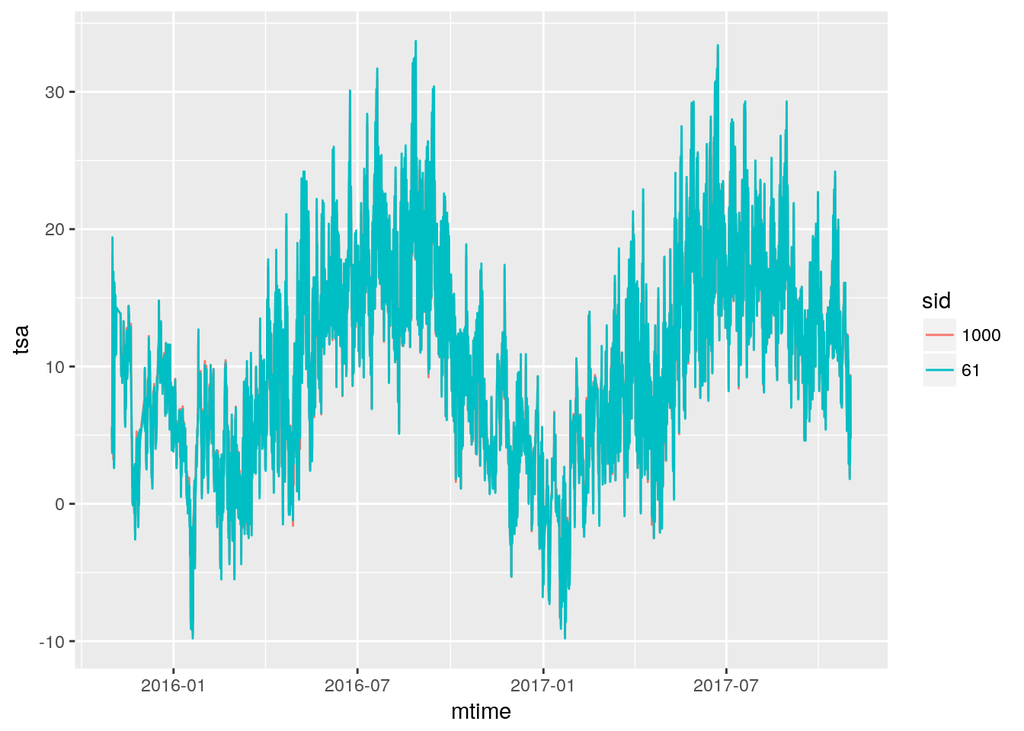

Time series

## Density

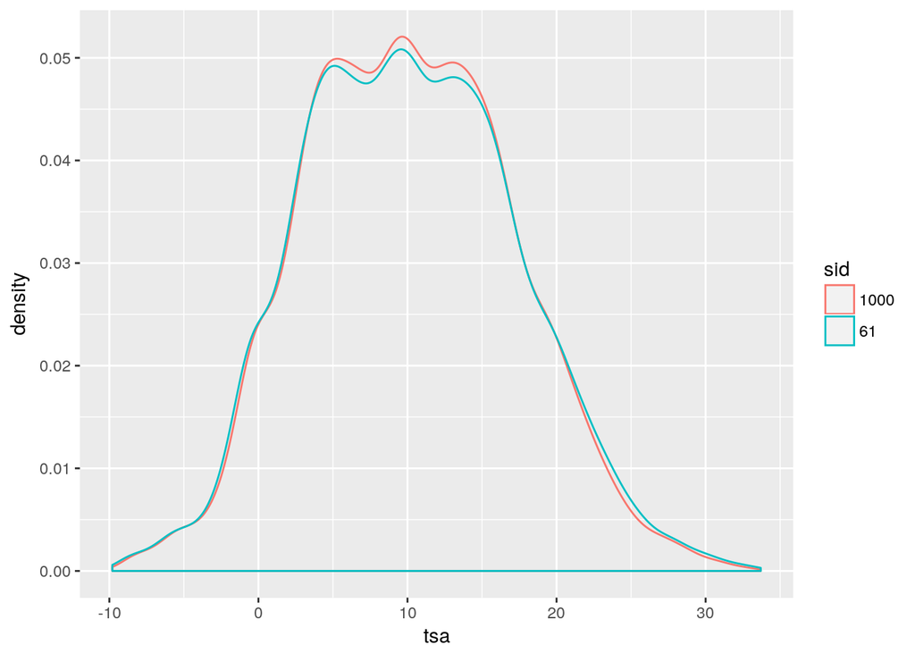

Density

## Scatter

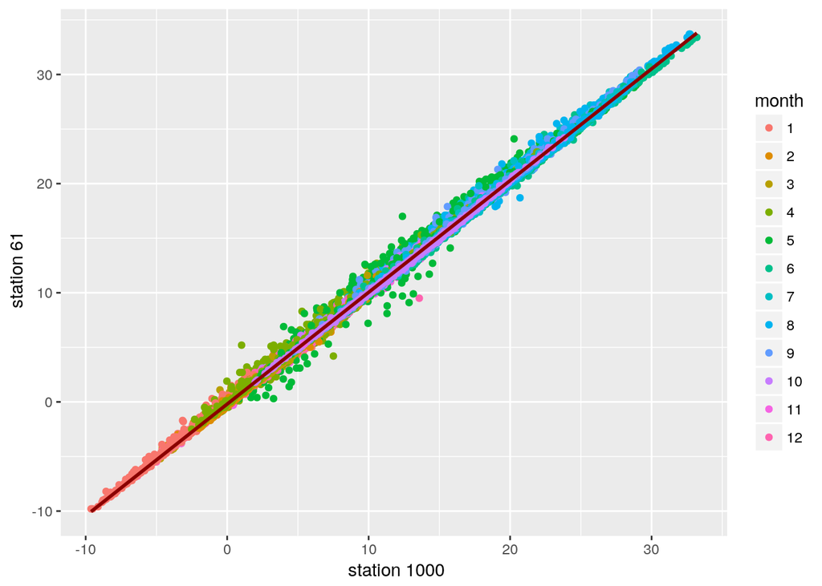

Scatter plot

# First insights

## Similarity

Datasets seem in accordance …

- but to which extent ?
- How can we quantify this degree of similarity ?
- Even if a certain degree of similarity : Pameseb seems warmer

## Temperature difference investigation

What can be infered by studying the temperature differences rather than their correlation ?

# Investigating the temperature difference

## Bland-Altman analysis

We can use a [Bland Altman analysis](https://pokyah.github.io/howto/assessing-the-agreement-between-2-quantitative-methods-of-measurements-understanding-the-Bland-Altman-analysis/) to measure the agreement level between the 2 stations.

It consists to take observations pair by pair, and plot their means vs. their differences.

In our case we choose to plot `IRM - Pameseb`.

## Vizualizing Bland-Altman analyis

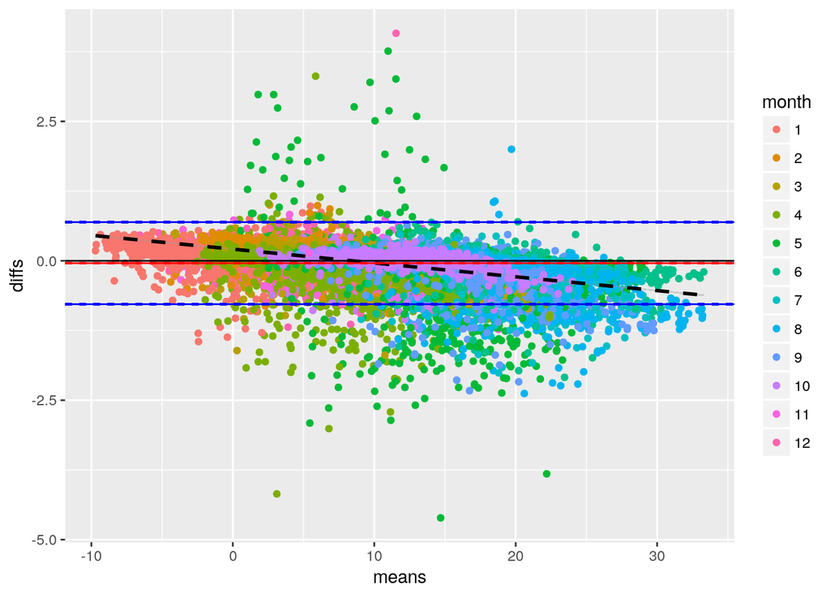

## Plausible hypothesis to investigate

The 2 stations are actually different in their design. While the **RMI** is equipped with a **Stevenson radiation screeen mechanically ventiled**, __Pameseb is equipped with a **custom screen without mechanical ventilation**

We can assume that it exists :

1. an overheating of the Pameseb shelter compared to RMI during periods of **High irradiance and low wind** due to the lack of ventilation system at Pameseb that may significantly increase the measured temperature.
2. an overcooling of the RMI shelter compared to Pameseb during periods of **Low irradiance + stratified air** situation due to the fact that the ventilation pumps air located 50 cm below the temperature sensor.

## Visualising the 2 designs

[figure not shown]

# Questioning the potential effect of the ventilation

## Strategy

We can filter the dataset to only keep records corresponding to specific situations :

- Do we still see a positif bias What happens when we are in situations of low irradiance ang high wind ? `vvt > vvt_mean && ens < 100`
- Do we see the same trend in temperature differences when considering situations of **low irradiance and high-wind** situations only ?
- Filtering the dataset by keeping situations where : `vvt > vvt_mean && ens < 100`

## Low irradiance and high wind BA Plot

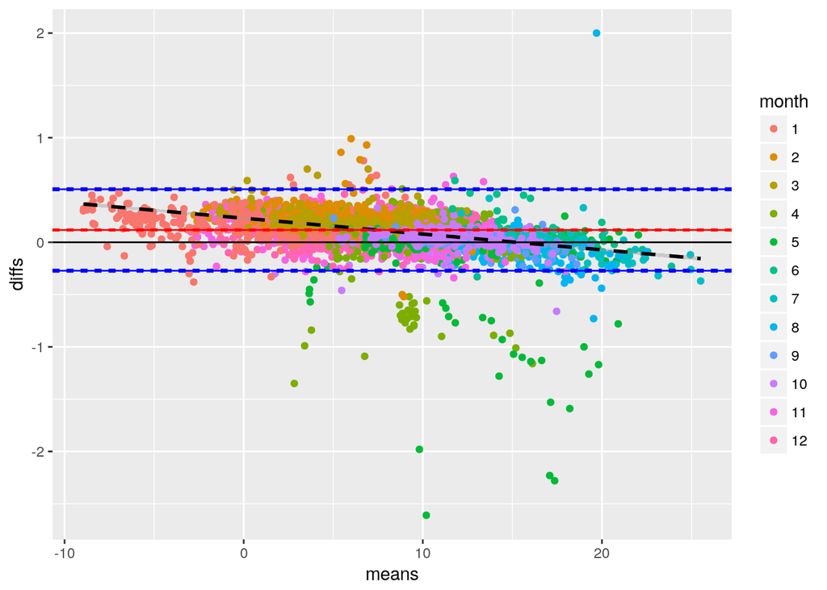

## What the Low irradiance and high wind BA plot tells us ?

- It exists a systematic **bias** of 0.1175583
- The **limits of agreement** are -0.271789 and 0.5069055 °C. *These lines tell us how far apart measurements by 2 methods were more likely to be for most individuals.*
- Considering the limits of agreement CI (-0.271789 and 0.5069055 ), we can tell that we are 95 % certain that the methods do not disagree (if maximum allowed difference is 1°C)
- The differences are still present but are clearly **less important**. Some discrepancies due to outliers
- Even with no irradiance, the rising trend is still present. How can this be ? According to RMI, the ventilation system pumps up air 50 cm below the sensor. While the atmosphere is stratified, the RMI shelter might be ventiled with colder air than the one it is supposed to measure…
- ==> So the rising trend might also be due to an artifical “over-cooling” rather than the combined effect of high irradiance + low wind only

## Statistics of the Low irradiance and high wind

low irradiance & high wind tsa summary stats

| id | sid | poste | sum | mean | min | max | sd | var | q25 | q50 | q75 |
| --- | --- | --- | --- | --- | --- | --- | --- | --- | --- | --- | --- |
| 31 | 61 | Humain | 31017.60 | 7.37 | -9.1 | 25.70 | 5.23 | 27.33 | 3.90 | 7.2 | 10.50 |
| 64 | 1000 | Humain | 31512.05 | 7.49 | -8.8 | 25.33 | 5.15 | 26.52 | 3.98 | 7.3 | 10.64 |

Strangely, IRM is globally **warmer**

- even if the temperature difference for high mean temperature is stil positive (`T°pameseb > T°IRM`) !
- even it might be subject to artifical over-cooling when the air is stratified
- ==> Hypothesis : when the shelters stop to receive direct solar radiation, we might expect that the Pameseb one cools quicker due to its less important inertia ?

## Considering the high irradiance and low wind situations

We can have a quick comparative lookat the **low-wind and high irradiance** situtions only to better grasp the effect of ventilation

## High Irradiance & Low wind Balnd-Altman

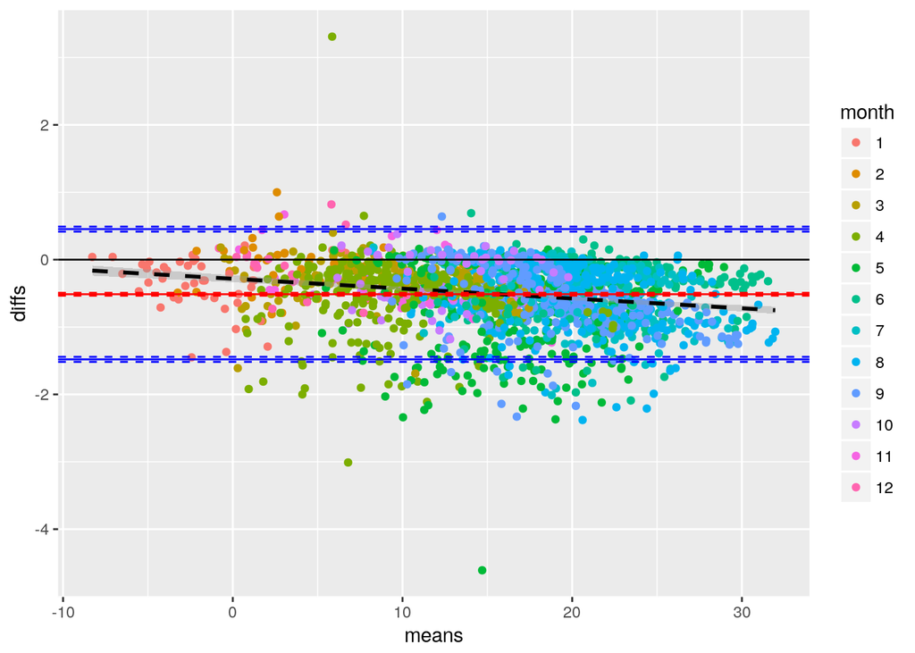

## What the High irradiance and low wind BA plot tells us ?

==> **prior to the integration of the 2 networks in the spatialization process, a correction model needs to be applied to the temperature data produced by the CRA-W AWS ne2rk**.

## Summarizing the examination of a ventilation mechanism

# Solving the disagreement

## Strategy

We can build a temperature correction model based on irradiance and wind speed conditions

# Conclusions, perspectives and colofon

## Conclusions

- prior to spatialization, a correction model needs to be applied before integrating the 2 networks

## Perspectives

- Once finished, we plan to submit this work to the “Weather” Journal of the RMETS.
- title idea : > Quantitative intercomparison of 2 years hourly records of temperature and relative humidity measured by 2 different types of professional-grade automatic weather stations at Humain, Belgium

## Colofon

- This report is still in major revision phase. **Consider it as a first draft version**.
- This document was generated using R software with the [knitr library](https://deanattali.com/2015/03/24/knitrs-best-hidden-gem-spin/)
- The interactive plots are rendered from ggplot by [plotly](https://plot.ly).
- The source code of the analysis and this presentation is availbale on [github](https://github.com/pokyah/AWS-Humain-comparison)